# Data Warehouse

Avances del Proyecto Final

Maximiliano Galoto

# 1 - Introduccion

Volver al Inicio

Un Data Warehouse es un almacén electrónico donde generalmente una empresa u organización mantiene una gran cantidad de información. Los datos de un data warehouse deben almacenarse de forma segura, fiable, fácil de recuperar y fácil de administrar.

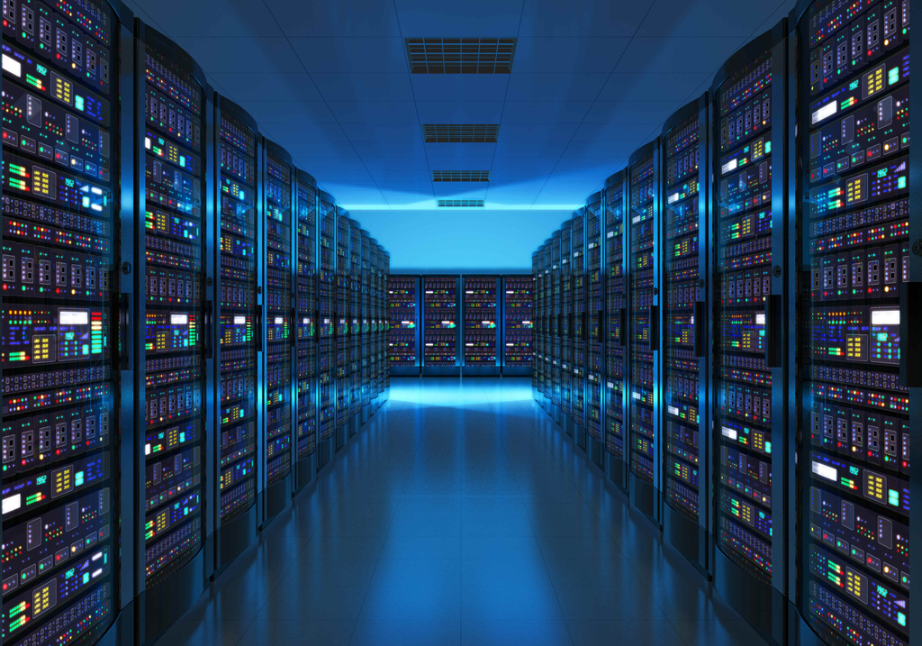

El concepto de data warehouse se originó en 1988 con el trabajo de los investigadores de IBM, Barry Devlin y Paul Murphy aunque el término data warehouse fue acuñado por William H. Inmon, el cual es conocido como el padre de Data Warehousing. Inmon describió un data warehouse como una colección de datos orientada a un tema específico, integrado, variante en el tiempo y no volátil, que soporta el proceso de toma de decisiones.

# 2 - My Sql

Volver al Inicio

[figure not shown]

Es un sistema de gestión de bases de datos relacional desarrollado bajo licencia dual: Licencia pública general/Licencia comercial por Oracle Corporation y está considerada como la base de datos de código abierto más popular del mundo, y una de las más populares en general junto a Oracle y Microsoft SQL Server, todo para entornos de desarrollo web.

A continuacion se encuentra un link con los instructivos para poder descargar e instalar My Sql:

[Guia de Instalacion de My Sql](https://docs.google.com/document/d/1GrStEE5YxDCRqYwWI0LASCCqiel2qooD/edit?usp=sharing&ouid=107665703043742500688&rtpof=true&sd=true)

# 3 - Descripcion del proyecto

Volver al Inicio

*Temática para el trabajo final:*

**Base de datos de una *Empresa de Medicina Prepaga* donde se va a hacer foco en un modelo de esquema [copo de nieve](https://es.wikipedia.org/wiki/Esquema_en_copo_de_nieve).**

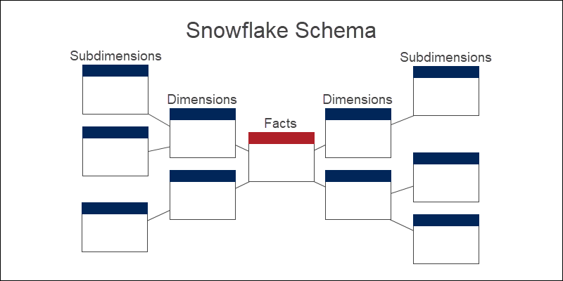

# 4 - Descripción de las tablas

Volver al Inicio

*Tablas, descripción y atributos:*

A continuación se detallaran cada una de las tablas que componen el DER con sus atributos y descripciones:

$$\textbf{Tabla: Afiliado }$$
|

| $$\textbf{Atributos}$$ | $$\textbf{Descripcion}$$ |
| --- | --- |
| $$Id\:Afiliado$$ | $$INT \:NOT\: NULL\: PRIMARY \:KEY\: AUTO\:INCREMENT$$ |
| $$Nombre$$ | $$VARCHAR(50) \:NOT \:NULL$$ |
| $$Apellido$$ | $$VARCHAR(50) \:NOT \:NULL$$ |
| $$Email$$ | $$VARCHAR(50) \:NOT \:NULL$$ |
| $$Telefono$$ | $$INT \:NOT \:NULL$$ |
| $$Fecha\:Nacimiento$$ | $$DATE \:NOT \:NULL$$ |
| $$Domicilio$$ | $$VARCHAR(50) \:NOT \:NULL$$ |
| $$Estado\:Civil$$ | $$VARCHAR(50) \:NOT \:NULL$$ |
| $$Dni$$ | $$INT \:NOT \:NULL$$ |
| $$Id\:Ocupacion$$ | $$INT \:NOT\: NULL\: FOREIGN \:KEY$$ |
| $$Id\:Plan$$ | $$INT \:NOT\: NULL\: FOREIGN \:KEY$$ |

*Esta tabla contiene los atributos de los afiliados de la empresa de medicina prepaga, podemos observar el ID como Primary Key y por ultimo dos FK que hacen referencia a la ocupación del empleado y el plan. Estas serán dos tablas que se crean a parte para no repertir datos.*

*Un ejemplo sencillo: La ocupación puede ser empleado bajo relación de dependencia, monotributista, desempleado o jubilado. Estos datos se pondrán aparte en una tabla llamada *ocupacion_afiliado* y en la tabla *afiliado* solo de pondrá el numero de ID ya que al ir dando de alta a los afiliados en el sistema nos ahorrariamos espacio en la base de datos al no tener que repetir tantos caracteres por fila y solamente completar con el ID de ocupacion que viene de la tabla *ocupacion_afiliado*.*

$$\textbf{Tabla: Ocupacion Afiliado }$$
|

| $$\textbf{Atributos}$$ | $$\textbf{Descripcion}$$ |
| --- | --- |
| $$Id\:Ocupacion$$ | $$INT \:NOT\: NULL\: PRIMARY \:KEY\: AUTO\:INCREMENT$$ |
| $$Ocupacion$$ | $$VARCHAR(50) \:NOT \:NULL$$ |

*Esta tabla contiene los siguientes datos: *Bajo relacion de dependencia, monotributista, desempleado y jubilado*.*

$$\textbf{Tabla: Plan Afiliado }$$
|

| $$\textbf{Atributos}$$ | $$\textbf{Descripcion}$$ |
| --- | --- |
| $$Id\:Plan$$ | $$INT \:NOT\: NULL\: PRIMARY \:KEY\: AUTO\:INCREMENT$$ |
| $$Nombre$$ | $$VARCHAR(50) \:NOT \:NULL$$ |

*Esta tabla contiene los siguientes datos: *Medium y Premium*.*

$$\textbf{Tabla: Medico }$$
|

| $$\textbf{Atributos}$$ | $$\textbf{Descripcion}$$ |
| --- | --- |
| $$Id\:Medico$$ | $$INT \:NOT\: NULL\: PRIMARY \:KEY\: AUTO\:INCREMENT$$ |
| $$Nombre$$ | $$VARCHAR(50) \:NOT \:NULL$$ |
| $$Apellido$$ | $$VARCHAR(50) \:NOT \:NULL$$ |
| $$Fecha\:Nacimiento$$ | $$DATE \:NOT \:NULL$$ |
| $$Domicilio$$ | $$VARCHAR(50) \:NOT \:NULL$$ |
| $$Telefono$$ | $$INT \:NOT\: NULL$$ |

*Esta tabla contiene los datos de los médicos que prestan su servicio a distintos centros médicos.*

$$\textbf{Tabla: Centro Medico }$$
|

| $$\textbf{Atributos}$$ | $$\textbf{Descripcion}$$ |
| --- | --- |
| $$Id\:Centro$$ | $$INT \:NOT\: NULL\: PRIMARY \:KEY\: AUTO\:INCREMENT$$ |
| $$Nombre$$ | $$VARCHAR(50) \:NOT \:NULL$$ |
| $$Dirección$$ | $$VARCHAR(50) \:NOT \:NULL$$ |
| $$Teléfono$$ | $$INT \:NOT \:NULL$$ |
| $$Cod\:Postal$$ | $$INT \:NOT \:NULL$$ |
| $$Email$$ | $$VARCHAR(50) \:NOT \:NULL$$ |
| $$Especialidad\:Principal$$ | $$VARCHAR(50) \:NOT \:NULL$$ |

$$\textbf{Tabla: Consulta }$$
|

| $$\textbf{Atributos}$$ | $$\textbf{Descripcion}$$ |
| --- | --- |
| $$Id\:Consulta$$ | $$INT \:NOT\: NULL\: PRIMARY \:KEY\: AUTO\:INCREMENT$$ |
| $$Consulta$$ | $$VARCHAR(50) \:NOT \:NULL$$ |
| $$Diagnostico$$ | $$VARCHAR(50) \:NOT \:NULL$$ |

*Esta tabla contiene los datos de las consultas de los afiliados y los diagnosticos posterior a la consulta.*

$$\textbf{Tabla: Turnos }$$
|

| $$\textbf{Atributos}$$ | $$\textbf{Descripcion}$$ |
| --- | --- |
| $$Id\:Turno$$ | $$INT \:NOT\: NULL\: PRIMARY \:KEY\: AUTO\:INCREMENT$$ |
| $$Fecha$$ | $$DATE \:NOT \:NULL$$ |
| $$Id\: Medico$$ | $$INT \:NOT\: NULL\: FOREIGN \:KEY$$ |
| $$Id\: Afiliado$$ | $$INT \:NOT\: NULL\: FOREIGN \:KEY$$ |
| $$Id\: Consulta$$ | $$INT \:NOT\: NULL\: FOREIGN \:KEY$$ |
| $$Id\:Centro$$ | $$INT \:NOT\: NULL\: FOREIGN \:KEY$$ |

*Esta tabla contiene los datos del turno. Se conecta con varias tablas, entre ellas la de consulta. Una vez registrado el turno en la base de datos y luego de la consulta se completan los valores en la tabla consulta con el diagnostico final.*

$$\textbf{Tabla: Proveedor }$$
|

[output not shown]

*La tabla contiene todos los datos de los proveedores que se van dando de alta. No tiene muchos movimientos en general.*

$$\textbf{Tabla: Tipo Insumo }$$
|

| $$\textbf{Atributos}$$ | $$\textbf{Descripcion}$$ |
| --- | --- |
| $$Id\:Tipo\:Insumo$$ | $$INT \:NOT\: NULL\: PRIMARY \:KEY\: AUTO\:INCREMENT$$ |
| $$Tipo\:Insumo$$ | $$VARCHAR(50) \:NOT \:NULL$$ |

*Tabla que contiene datos sobre el tipo de insumo que compran los centros medicos. No tiene muchos movimientos.*

$$\textbf{Tabla: Insumos }$$
|

| $$\textbf{Atributos}$$ | $$\textbf{Descripcion}$$ |
| --- | --- |
| $$Id\:Insumo$$ | $$INT \:NOT\: NULL\: PRIMARY \:KEY\: AUTO\:INCREMENT$$ |
| $$Nombre$$ | $$VARCHAR(50) \:NOT \:NULL$$ |
| $$Id\:Centro$$ | $$INT \:NOT\: NULL\: FOREIGN \:KEY$$ |
| $$Id\:Tipo\:Insumo$$ | $$INT \:NOT\: NULL\: FOREIGN \:KEY$$ |
| $$Id\:Proveedor$$ | $$INT \:NOT\: NULL\: FOREIGN \:KEY$$ |

*Esta tabla contiene los datos de cada uno de los insumos.*

$$\textbf{Tabla: Centro Medico Insumos }$$
|

| $$\textbf{Atributos}$$ | $$\textbf{Descripcion}$$ |
| --- | --- |
| $$Id\:Centro\:Medico\:Insumos$$ | $$INT \:NOT\: NULL\: PRIMARY \:KEY\: AUTO\:INCREMENT$$ |
| $$Id\:Centro$$ | $$INT \:NOT\: NULL\: FOREIGN \:KEY$$ |
| $$Id\:Insumo$$ | $$INT \:NOT\: NULL\: FOREIGN \:KEY$$ |

*Tabla que conecta de muchos a muchos los insumos con los centros medicos.*

$$\textbf{Tabla: Pagos }$$
|

[output not shown]

*Tabla que registra todos los pagos de todos los centros médicos.*

$$\textbf{Tabla: Cobros }$$
|

[output not shown]

*Tabla que registra todos los cobros de todos los centros médicos.*

$$\textbf{Tabla: Medio Operacion }$$
|

| $$\textbf{Atributos}$$ | $$\textbf{Descripcion}$$ |
| --- | --- |
| $$Id\:Medio\:Operacion$$ | $$INT \:NOT\: NULL\: PRIMARY \:KEY\: AUTO\:INCREMENT$$ |
| $$Tipo\:Medio\:Operacion$$ | $$VARCHAR(50) \:NOT \:NULL$$ |

*Tabla que registra todos medios financieros de pagos: *Tarjeta de Debito, Crédito, Efectivo y Transferencias*.*

# 5 - Diagrama Entidad de Relacion

Volver al Inicio

**Un diagrama entidad-relación, también conocido como modelo entidad relación o ERD, es un tipo de diagrama de flujo que ilustra cómo las “entidades”, como personas, objetos o conceptos, se relacionan entre sí dentro de un sistema. Los diagramas ER se usan a menudo para diseñar o depurar bases de datos relacionales en los campos de ingeniería de software, sistemas de información empresarial, educación e investigación.**

En **[este link](https://app.diagrams.net/)** se puede elaborar un DER preliminar para luego trabajarlo en una base de datos.

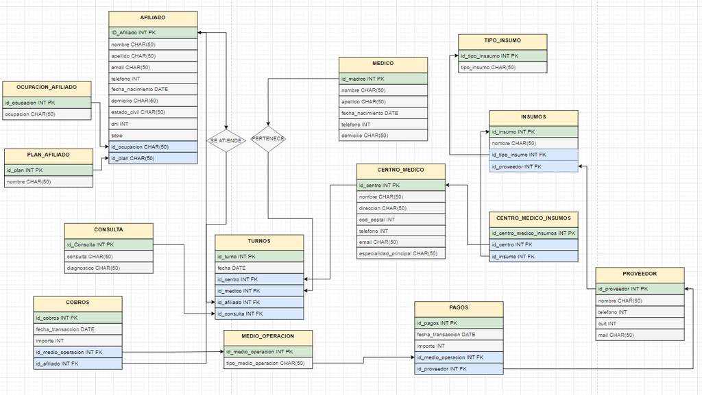

Luego de crear las tablas en My Sql podemos ver el Reverse Engineer.

La ingeniería inversa o retroingeniería es el proceso llevado a cabo con el objetivo de obtener información o un diseño a partir de un producto, con el fin de determinar cuáles son sus componentes y de qué manera interactúan entre sí y cuál fue el proceso de fabricación.

[figure not shown]

La siguiente imagen representa el Reverse Engineer de la base de datos creada:

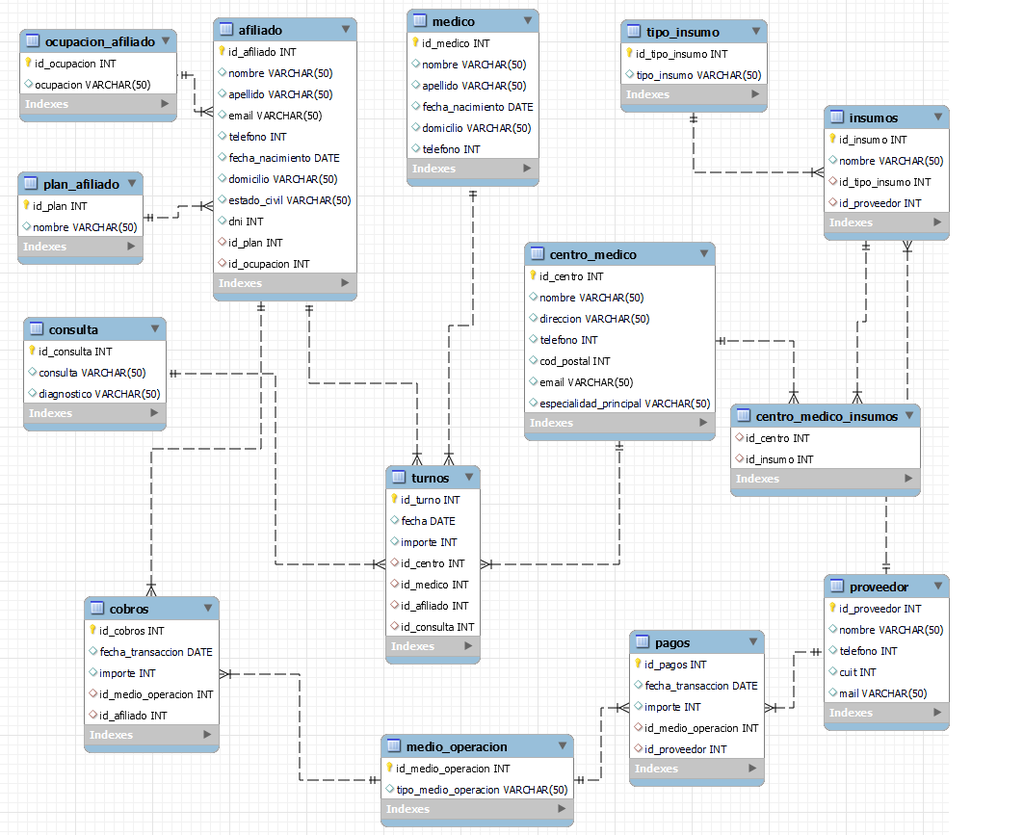

# 6 - Codigo MySql desde Python

Volver al Inicio

**En el siguiente enlace se encuentra el código para crear la base de datos desde Python:**

[figure not shown]

[Link Github Codigo](https://github.com/MGaloto/mysql_creando_database)

# 7 - Inserción de datos

Volver al Inicio

*Metodologia utilizada:* **Los valores en cada una de las tablas se insertaron desde archivos .csv.**

Los archivos son los siguientes:

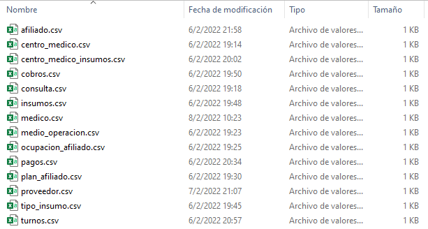

*Ejemplo tabla afiliados:*

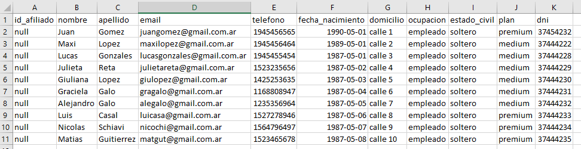

A continuación se adjuntan scripts de los pasos para importar los datos y MySql final:

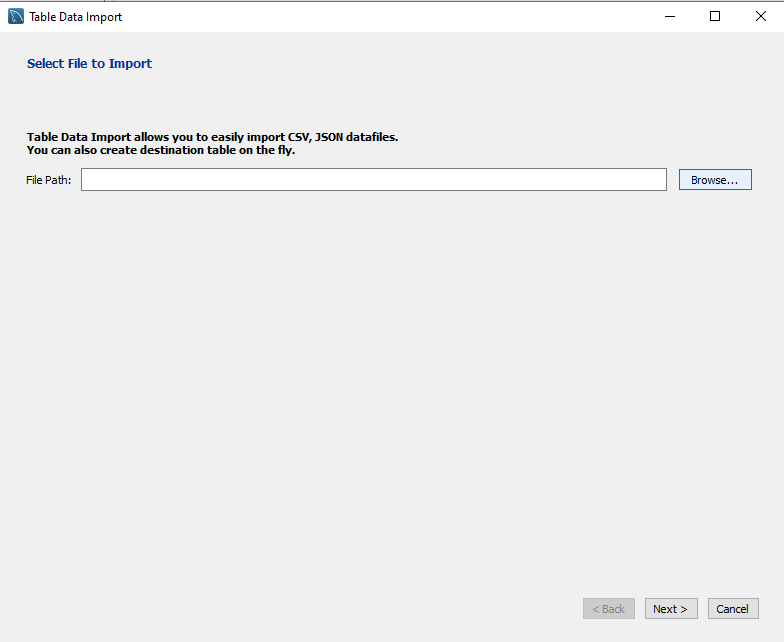

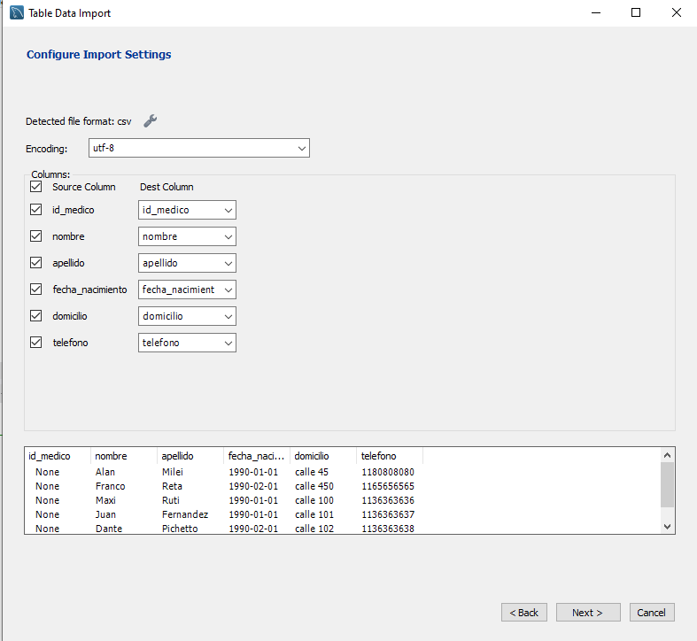

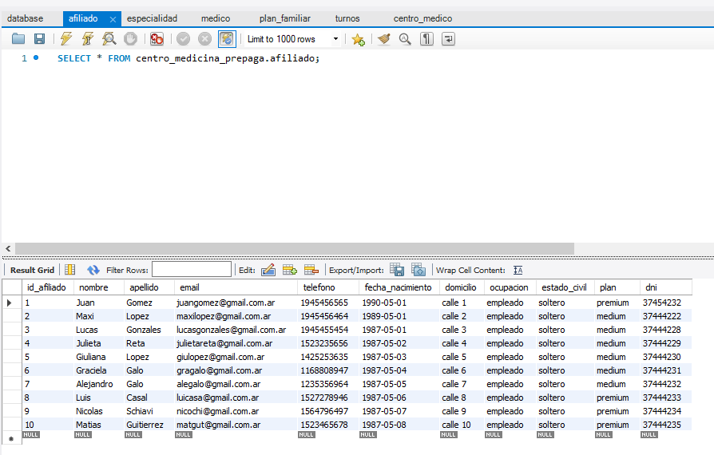

# 8 - Vistas

Volver al Inicio

*A continuación se adjuntan los scripts de las vistas*

*El código SQL de las vistas se encuentra en el siguiente link:* [Github Codigo](https://github.com/MGaloto/mysql_creando_database/blob/main/database.py)

*1) Vista 1:*

*Consulta y Diagnostico por Afiliado*

*Esta vista permite guardarnos en una tabla aparte todos los turnos solicitados por los afiliados dados de alta en el sistema. Nos sirve para estar actualizados de los ultimos turnos ya que esta ordenada por fecha.*

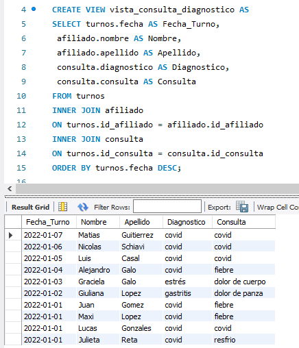

*2) Vista 2*

*Que medico atendió a cada paciente:*

*Esta vista creada nos sirve para visualizar forma rapida mediante su consulta sobre que medicos atendieron a que paciente en determinada fecha.*

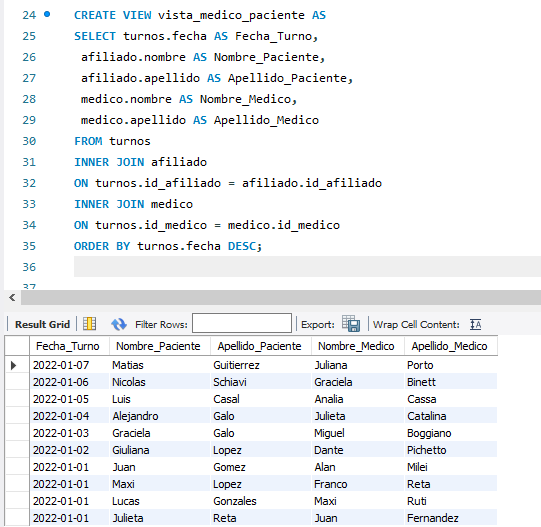

*3) Vista 3*

*Que medico atiende en cada centro medico:*

*Esta vista permite que podamos visualizar de forma rapida que medicos atienden en los centros medicos.*

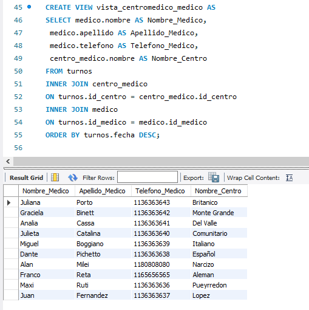

# 9 - Funciones

Volver al Inicio

Por definición es importante indicar que una función es un conjunto de instrucciones SQL que realizan una tarea específica de manera automática. Una función acepta entradas en forma de parámetros y devuelve un valor.

*A continuación se adjuntan los scripts de las funcioness*

*1) Función 1:*

*Función donde ingresamos un CHAR y nos devuelve un NUMERIC*

*Ingresamos el diagnostico y nos regresa el porcentaje de pacientes con el diagnostico ingresado de nuestra base de datos*

*En la parte inferior de la imagen adjunta se puede ver el resultado de la función una vez ingresado un CHAR.*

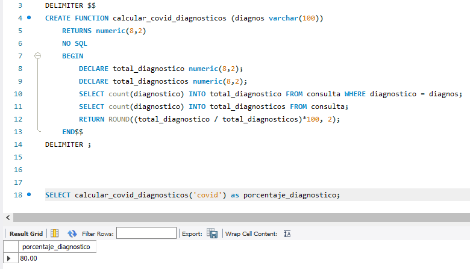

*2) Función 2:*

*Función que no requiere un valor de entrada.*

*Esta funcion nos calcula automaticamente la diferencia entre ingresos y egresos de todos los centros medicos.*

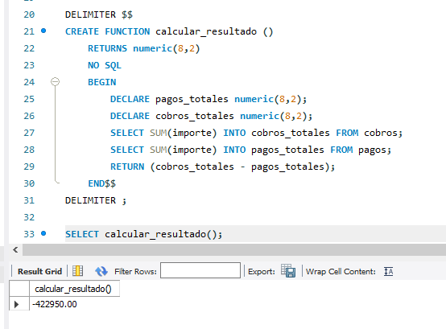

# 10 - Stored Procedures

Volver al Inicio

**Un stored procedure es un programa (o procedimiento) almacenado físicamente en una base de datos. Su implementación varía de un gestor de bases de datos a otro. La ventaja de un procedimiento almacenado es que al ser ejecutado, en respuesta a una petición de usuario, es ejecutado directamente en el motor de bases de datos, el cual usualmente corre en un servidor separado. Como tal, posee acceso directo a los datos que necesita manipular y sólo necesita enviar sus resultados de regreso al usuario, deshaciéndose de la sobrecarga resultante de comunicar grandes cantidades de datos salientes y entrantes.**

*A continuación se adjuntan los scripts de los Stored Procedures*

*1) Stored Procedure 1:*

*En el siguiente Stored Procedure insertamos valores en la tabla turno con el ID creado anteriormente en la tabla consulta.*

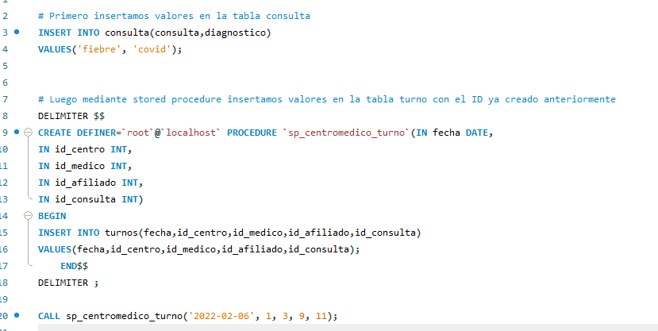

*2) Stored Procedure 2:*

*El siguiente Stored Procedure ejecuta un comando que nos permite ordenar la tabla que queramos por una variable.*

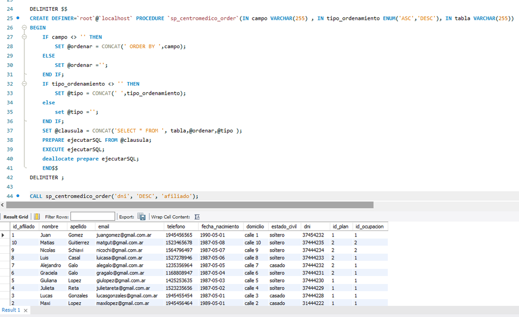

# 11 - Triggers

Volver al Inicio

Un disparador o trigger es una funcionalidad que la base de datos ejecuta de forma automática cuando se realiza una operación de tipo Insert, Update o Delete en una tabla o vista, o cuando se ejecuta una consulta SQL sobre una tabla o vista.

Un trigger no puede existir sin una tabla asignada, podemos crear muchos triggers para una tabla.

Cuando un evento ya sea de tipo Insert, Update o Delete se realiza en una tabla que contiene uno o varios triggers, en la tabla que creamos que comienza con logs se ejecuta tambien ese evento modificando la tabla. Hay dos comandos que podemos utilizar, el Before y el After, con el primero cuando insertamos datos en la tabla principal primero ingresaran al triger y luego a la tabla principal, con el After ocurre todo lo contrario.

*A continuación se adjuntan los scripts de los Triggers*

*1) Triggers 1:*

*En el siguiente Trigger se crea un log para la tabla afiliados y luego de insertar los datos en la tabla afiliados van a parar al trigger creado.*

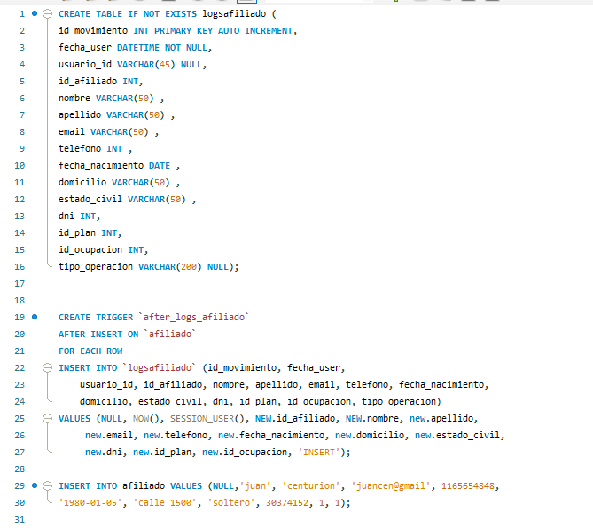

*Lo contrario sucede con la próxima imagen que es un Before.*

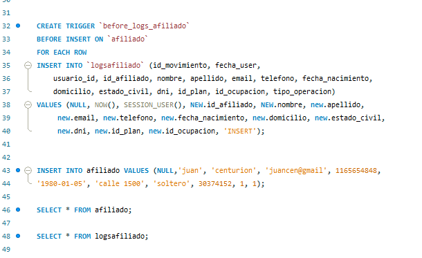

*2) Triggers 2:*

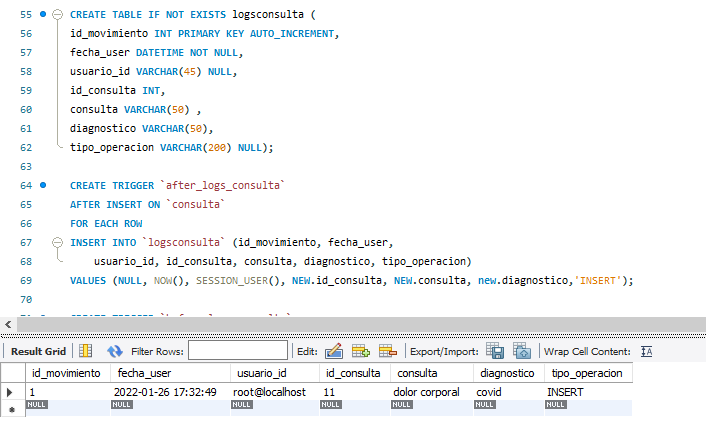

*Lo contrario sucede con la próxima imagen que es un Before.*

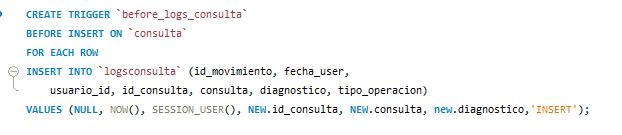

# 12 - Permisos

Volver al Inicio

Sentencias GRANT y REVOKE

Utilizando la sentencia GRANT podemos dar permisos al usuario creado para que pueda hacer los siguientes comandos sobre la base de datos o una tabla en particular: SELECT, INSERT, UPDATE y DELETE.

Con la sentencia REVOKE le quitamos permisos al usuario.

*A continuación se adjuntan los scripts de los Usuarios creados y las sentencias*

*Creamos el usuario_uno y el usuario_dos donde al primero le damos permiso con la sentencia GRANT para que solo pueda hacer comandos SELECT. Al usuario_dos le damos permiso para que pueda alterar, seleccionar e insertar datos.*

*Con la sentencia REVOKE le quitamos a ambos usuarios la posibilidad de eliminar registros.*

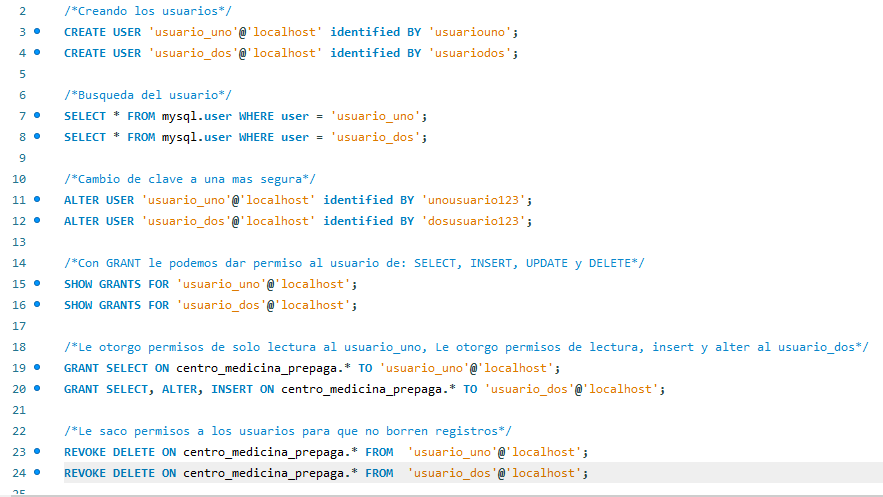

*SHOW GRANTS para el usuario_uno.*

*Podemos ver que solo tiene permiso para la sentencia SELECT en la base de datos.*

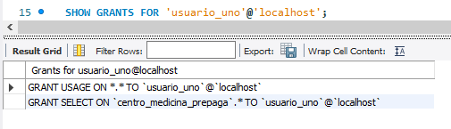

*SHOW GRANTS para el usuario_dos.*

*Podemos ver que tiene permiso para la sentencia SELECT, INSERT y ALTER en la base de datos.*

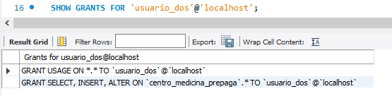